# Predicting survival in the Titanic shipwreck!

Tech talk S04 E07 at iTech

By: Caroline Costa caroline.costa@itech.media

[figure not shown]

## Aims

- We want to build a machine learning model that can predict Jack's death and Rose's survival
- We want to understand why they survived or not

## Approach

We will build a tree-based classification model that can predict Jack's and Rose's fate in the shipwreck and use SHAP to understand the contribution of individual features on the predictions.

We will follow the steps below:

- Exploration: Investigate trends and patterns in the data
- Pre-processing: Prepare data for modelling
- Modelling: Build classifiers and experiment with different parameters
- Refinement: Refine the model by tuning hyperparameters and improving the data
- Understanding the model's decisions: Investigate feature contributions in global and individual predictions

## Exploration

### Get your data

```python
# read datasets
titanic = pd.read_csv('train.csv')
```

```python
titanic.head()
```

|  | PassengerId | Survived | Pclass | Name | Sex | Age | SibSp | Parch | Ticket | Fare | Cabin | Embarked |
| --- | --- | --- | --- | --- | --- | --- | --- | --- | --- | --- | --- | --- |
| 0 | 0 | 1 | 1 | Oconnor, Frankie | male | NaN | 2 | 0 | 209245 | 27.14 | C12239 | S |
| 1 | 1 | 0 | 3 | Bryan, Drew | male | NaN | 0 | 0 | 27323 | 13.35 | NaN | S |
| 2 | 2 | 0 | 3 | Owens, Kenneth | male | 0.33 | 1 | 2 | CA 457703 | 71.29 | NaN | S |
| 3 | 3 | 0 | 3 | Kramer, James | male | 19.00 | 0 | 0 | A. 10866 | 13.04 | NaN | S |
| 4 | 4 | 1 | 3 | Bond, Michael | male | 25.00 | 0 | 0 | 427635 | 7.76 | NaN | S |

### Feature descriptions

PassengerID: ID number

**Survived:** Survival 0 = No, 1 = Yes

**Pclass:** Ticket class 1 = 1st, 2 = 2nd, 3 = 3rd

Name: Name

**Sex:** Sex - Male or Female

**Age:** age in years

**SibSp:** # of siblings / spouses aboard the Titanic

**ParCh:** # of parents / children aboard the Titanic

Ticket: Ticket number

**Fare:** Passenger fare

Cabin: Cabin number

**Embarked:** Port of Embarkation C = Cherbourg, Q = Queenstown, S = Southampton

### Devide into training and test sets

Before we dive into our data, we want to first set a test aside. We'll use the test set to evaluate our model on data neither nor the model has seen during training. This will avoid what is called snooping bias, where we influence the outcome of the model with too much knowledge of the data.

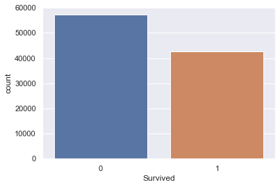

```python
ax = sns.countplot(x="Survived", data=titanic)
```

```python
# split dataset using StratifiedShuffleSplit to avoid imbalanced train and test sets
titanic_labels = pd.DataFrame(titanic['Survived']).copy()
titanic.drop(['Survived'], axis=1, inplace=True)

split = StratifiedShuffleSplit(n_splits=1, test_size=0.2, random_state=42)
for train_index, test_index in split.split(titanic, titanic_labels):
    titanic_train, titanic_test = titanic.loc[train_index], titanic.loc[test_index]
    titanic_labels_train, titanic_labels_test = titanic_labels.loc[train_index], titanic_labels.loc[test_index]

print('Training set:\n', titanic_labels_train['Survived'].value_counts()/len(titanic_labels_train['Survived']))
print('Test set:\n', titanic_labels_test['Survived'].value_counts()/len(titanic_labels_test['Survived']))
```

```
Training set:
 0    0.572263
1    0.427737
Name: Survived, dtype: float64
Test set:
 0    0.57225
1    0.42775
Name: Survived, dtype: float64
```

### Looking at the training data

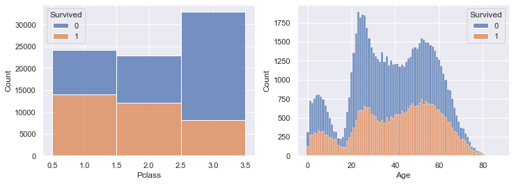

```python
fig, axs = plt.subplots(1,2, figsize=(12,4))
sns.histplot(x="Pclass", data=titanic_train_labelled, hue="Survived", ax=axs[0], multiple='stack', discrete=True)
sns.histplot(x="Age", data=titanic_train_labelled, hue="Survived", ax=axs[1], multiple='stack', discrete=True)
plt.show()
```

People in the third class were more likely to die than people in higher classes.

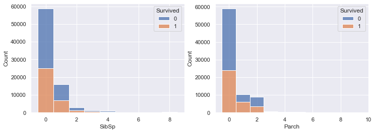

```python
fig, axs = plt.subplots(1,2, figsize=(12,4))
sns.histplot(x="SibSp", data=titanic_train_labelled, hue="Survived", ax=axs[0], multiple='stack', discrete=True)
sns.histplot(x="Parch", data=titanic_train_labelled, hue="Survived", ax=axs[1], multiple='stack', discrete=True)
plt.show()
```

People with no family onboard were also more likely to die.

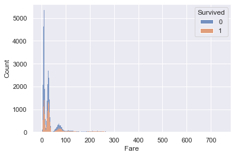

```python
fig, axs = plt.subplots(1,1, figsize=(6,4))
sns.histplot(x="Fare", data=titanic_train_labelled, hue="Survived", ax=axs, multiple='stack', discrete=True)
plt.show()
```

People who paid a lower fair were more likely to die.

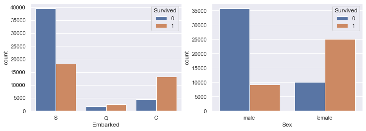

```python
fig, axs = plt.subplots(1,2, figsize=(12,4))
sns.countplot(x="Embarked", data=titanic_train_labelled, hue="Survived", ax=axs[0])
sns.countplot(x="Sex", data=titanic_train_labelled, hue="Survived", ax=axs[1])
plt.show()
```

- Men who embarked in Southampton and were more likely to die
- Women and people who embarked in Cherbourg were more likely to survive

#### Missing data

```python
titanic_train.isna().any()
```

```
Pclass      False
Sex         False
Age          True
SibSp       False
Parch       False
Fare         True
Embarked     True
dtype: bool
```

## Pre-processing

Prepare the data for modelling

### Create transformation pipeline

Based on the analysis above, we need to:

- Impute missing data
- Transform features from categorical to numerical, as the ML models we will use do not accept categorical features
- Normalize the data, which currently has very different scales. This might not be required for tree-based models, but most ML models require this step

```python
# create data transformation pipelines for categorical and numerical features separately
num_cols = ['Age', 'SibSp', 'Parch', 'Fare']
cat_cols = ['Pclass', 'Sex', 'Embarked']

# numerical features
num_pipeline = Pipeline([
    ('imputer', SimpleImputer(strategy='median')), # impute missing values
    ('std_scaler', StandardScaler()) # normalize data: standardization better when there outliers
])

# categorical features
cat_pipeline = Pipeline([
    ('imputer', SimpleImputer(strategy='most_frequent')), # impute missing values
    ('one_hot', OneHotEncoder(drop='if_binary')) # categorical -> numerical
])

# build full pipeline and fit to training data
full_pipeline = ColumnTransformer([
    ('num', num_pipeline, num_cols),
    ('cat', cat_pipeline, cat_cols)
]).fit(titanic_train)
```

### Prepare the training set

```python
titanic_train_prep = full_pipeline.transform(titanic_train)
titanic_labels_train_prep = titanic_labels_train['Survived'].to_numpy(dtype=int)
```

### Prepare the test set

Let's add Jack and Rose to the test set

[figure not shown]

```python
# adding jack and rose to the test set so we don't train the model on them
jack = {'Pclass': 3,
        'Sex': 'male',
        'Age': 20,
        'SibSp': 0,
        'Parch': 0,
        'Fare': 7.8,
        'Embarked': 'S'}
jack_pd = pd.DataFrame(data=jack, index=[0])

rose = {'Pclass': 1,
        'Sex': 'female',
        'Age': 17,
        'SibSp': 1, # fiance
        'Parch': 1, # mother
        'Fare': 280,
        'Embarked': 'S'}
rose_pd = pd.DataFrame(data=rose, index=[0])

jack_and_rose = pd.concat([jack_pd, rose_pd], ignore_index=True)
jack_and_rose_labels = pd.DataFrame([0, 1], columns=['Survived'])

titanic_test = pd.concat([titanic_test, jack_and_rose], ignore_index=True)
titanic_labels_test = pd.concat([titanic_labels_test, jack_and_rose_labels], ignore_index=True)
```

```python
# apply pipeline to test set
titanic_test_prep = full_pipeline.transform(titanic_test)
titanic_labels_test_prep = titanic_labels_test['Survived'].to_numpy(dtype=int)
```

## Modelling

### Define an evaluation metric

For consistency with Kaggle, we will use **accuracy**, which gives a percentage of correct predictions, to measure model performance.

Accuracy is not always advisable as a classification metric, as it can be misleading, especially in unbalanced datasets. Typically, we would look at precision and recall. Have a look here: https://medium.com/@shrutisaxena0617/precision-vs-recall-386cf9f89488

Kaggle's leaderboard top accuracy stands at 0.8133. How close do we need to get? There's always an easy trap with Data Science models: never ending projects chasing after high model accuracy!

Let's be realistic and set our **"good enough"** target to be up to 5% less, so **77.26 accuracy**.

[figure not shown]

We also need to think about metrics that **measure impact/value**. That doesn't apply here, but think about:

- What accuracy/precision/recall mean in terms such as **time/money/lives** saved?
- What is the **cost** of getting our predictions wrong?

[figure not shown]

### Esblishing a baseline

Let's start with a simple model that uses a **single decision tree**. A decision tree classifier learns simple decision rules inferred from the data features.

**Advantages:**

- Simple and easy to setup
- Explainable (if limited to a few levels)

**Disadvantages:**

- Prone to overfitting: can easily learn the training set "by heart" but will not generalize to unseen data
- Requires little data preparation: no need for scaling or one-hot encoding
- Can be unstable because small variations in the data might result in a completely different tree
- Decision tree learners create biased trees if some classes dominate

More info: https://scikit-learn.org/stable/modules/tree.html#tree

```python
# train the classifier and generate predictions
tree_clf = DecisionTreeClassifier(random_state=42)
tree_clf.fit(titanic_train_prep, titanic_labels_train_prep)
tree_train_preds = tree_clf.predict(titanic_train_prep)
tree_test_preds = tree_clf.predict(titanic_test_prep)
```

```python
# compute accuracy
tree_train_acr = accuracy_score(titanic_labels_train_prep, tree_train_preds)
tree_test_acr = accuracy_score(titanic_labels_test_prep, tree_test_preds)
print('Tree accuracy on train {:1.2f} and test {:1.2f}'.format(tree_train_acr, tree_test_acr))
```

```
Tree accuracy on train 0.99 and test 0.69
```

The accuracy is much higher on the training set than on the test set. This means that the model if overfitting the traning set and can't generalize predictions to unseen data. Can we make it better?

```python
# limit model complex to avoid overfitting by setting  max_leaf_nodes=6
tree_clf = DecisionTreeClassifier(max_leaf_nodes=6, random_state=42)
tree_clf.fit(titanic_train_prep, titanic_labels_train_prep)
tree_train_preds = tree_clf.predict(titanic_train_prep)
tree_test_preds = tree_clf.predict(titanic_test_prep)
```

```python
tree_train_acr = accuracy_score(titanic_labels_train_prep, tree_train_preds)
tree_test_acr = accuracy_score(titanic_labels_test_prep, tree_test_preds)
print('Tree accuracy on train {:1.4f} and test {:1.4f}'.format(tree_train_acr, tree_test_acr))
```

```
Tree accuracy on train 0.7581 and test 0.7572
```

The model is much more balanced now and not too far from our target score of 0.77!

One of the advantages of the Decision tree is that we can visualize how it makes predictions by plotting the tree.

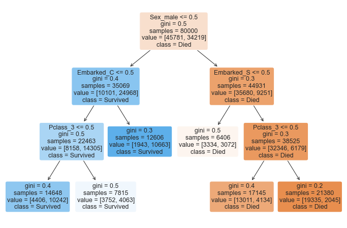

```python
fig, ax = plt.subplots(1, 1, figsize=(12,8))
tree.plot_tree(tree_clf, feature_names=feature_names, class_names=['Died', 'Survived'],
               filled=True, proportion=False, rounded=True, precision=1)
plt.show()
```

### Try a more complex model

Bring out the big guns, aka, **XGBoost**!

XGBoost is based on the ML framework of **Gradient Boosting**. The general idea of Gradient Boosting is to incrementally add decision trees to an ensemble to correct its predecessor, where the new predictor is fitted to the residual errors made by the previous predictor. So, **at each iteration, the model tries to improve on its errors.**

**How does it work?**

- Iteratively learning an ensemble of weak models on subsets of the data: can be done in parallel!
- Weighting each weak prediction according to each weak learners performance
- Combine the weighted predictions to obtain a single weighted prediction that is much better than the individual predictions themselves

XGBoost provides a library with a scalable, portable and accurate implementation of boosting. It is often a champion in Kaggle competitions and can even beat Neural Networks for certain problems.

**When to use XGBoost**

- Large number of training samples: <1000 and >100 features
- Mixture of categorical and numeric features or only numeric features
- Categorical only: catboost

**When *not* to use XGBoost**

- Image recognition, computer vision, natural language processing and understanding problems: these are best solved using deep-learning approaches
- Small training set, with less training samples than features: these usually require Bayesian models

Check it out here: https://xgboost.readthedocs.io/en/stable/index.html

```python
dtrain = xgb.DMatrix(titanic_train_prep, titanic_labels_train_prep)
dtest = xgb.DMatrix(titanic_test_prep, titanic_labels_test_prep)
```

```python
params = {"max_depth": 6, # default
          "eta": 0.3, # default
          "objective": "binary:hinge", # for binary classification
          "eval_metric": "error", # 1 - accuracy
         }
```

```python
def train_eval_model(params, dtrain, dtest, train_labels, test_labels):
    # train
    xgb_clf = xgb.train(params, dtrain)

    # run prediction
    xgb_train_preds = xgb_clf.predict(dtrain)
    xgb_test_preds = xgb_clf.predict(dtest)

    # compute accuracy
    xgb_train_acr = accuracy_score(train_labels, xgb_train_preds)
    xgb_test_acr = accuracy_score(test_labels, xgb_test_preds)
    print('XGBoost accuracy on train {:1.4f} and test {:1.4f}'.format(xgb_train_acr, xgb_test_acr))

    return xgb_clf
```

```python
xgb_clf = train_eval_model(params, dtrain, dtest, titanic_labels_train_prep, titanic_labels_test_prep)
```

```
XGBoost accuracy on train 0.7682 and test 0.7653
```

### Experiment with parameters

```python
params = {"max_depth": 20, # deeper trees
          "eta": 0.3, # default
          "objective": "binary:hinge", # for binary classification
          "eval_metric": "error", # 1 - accuracy
         }
xgb_clf_mf = train_eval_model(params, dtrain, dtest, titanic_labels_train_prep, titanic_labels_test_prep)
```

```
XGBoost accuracy on train 0.9441 and test 0.7240
```

The model is overfitting!

```python
params = {"max_depth": 6, # default
          "eta": 0.1, # slower learning rate
          "objective": "binary:hinge", # for binary classification
          "eval_metric": "error", # 1 - accuracy
         }
xgb_clf_eta = train_eval_model(params, dtrain, dtest, titanic_labels_train_prep, titanic_labels_test_prep)
```

```
XGBoost accuracy on train 0.6916 and test 0.6911
```

We're only making it worse. Let's try a more standardized approach

### Refinement

#### Fine-tune the model using cross-validatoin

```python
%%time
# using scikit-learn interface: XGBClassifier
xgb_model = xgb.XGBClassifier(objective="binary:hinge",
                              eval_metric="error")
cv_clf = GridSearchCV(xgb_model,
                      {'max_depth': [4, 6, 8, 10],
                       'eta': [0.1, 0.3, 0.6, 0.8, 1.0]
                      }
                     ).fit(titanic_train_prep, titanic_labels_train_prep)
```

```
CPU times: user 32min 49s, sys: 44.5 s, total: 33min 33s
Wall time: 3min 1s
```

```python
best_params = {**cv_clf.best_params_, **{"objective": "binary:hinge", "eval_metric": "error"}}
```

```python
xgb_clf_cv = train_eval_model(best_params, dtrain, dtest, titanic_labels_train_prep, titanic_labels_test_prep)
```

```
XGBoost accuracy on train 0.7682 and test 0.7653
```

Hardly any change! Refining parameters doesn't seem to be the best way to go.

#### What else could we try?

- Investigate if there are any subsets of the data where the model is performing poorly. Could we get more data? Could we improve that subset?
- Feature engineering: try combining and creating new features based on current ones
- Try different models such as Random Forest, LightGBM, Neural Networks, etc.
- Research what others have done: https://www.kaggle.com/competitions/titanic/code
- **Re-trace your steps:** we performed a lot of pre-processing steps without measuring the impact on the model! Consider using a tool for experiment tracking such as MLflow: https://mlflow.org/docs/latest/tracking.html

#### Other things to consider

- Do we need higher accuracy? Consider the **cost** (time, compute resources) versus **benefit** (impact, value)
- **Stay focused on your aims**: and don't get lost in the accuracy rabbit hole!

[figure not shown]

## Understanding the model's decisions

We will SHAP for this task, as it is more robust and accurate than tree-based feature importances.

SHAP (SHapley Additive exPlanations) is a **game theory** approach to explain the output of any machine learning model. It connects optimal credit allocation with local explanations using the classic **Shapley values** from game theory and their related extensions.

Essentially, the Shapley value is the **average expected marginal contribution** of one player after all possible combinations have been considered. It helps to determine a payoff for all of the players when each player might have contributed more or less than the others.

An interesting article about it: https://towardsdatascience.com/interpretable-machine-learning-with-xgboost-9ec80d148d27

Link to library: https://github.com/slundberg/shap

### Feature contributions

```python
explainer = shap.TreeExplainer(xgb_clf_cv) # using our best model - module for tree based models
shap_values = explainer.shap_values(features_pd)
```

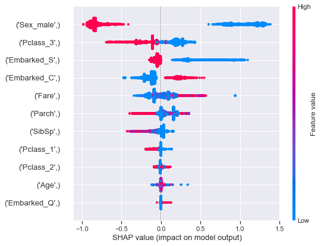

```python
shap.summary_plot(shap_values, features_pd)
```

### Predicting individual cases

We'll use our best model and make predictions on the test set, then see the result for Jack and Rose.

We'll also use the SHAP force plot to understand the prediction. In this plot, features pushing the prediction higher (survival) are shown in red, those pushing the prediction lower (death) are in blue

#### Jack

```python
print('Jack', result[int(xgb_cv_preds[jack_id])])
```

```
Jack Died
```

The model correctly predicts that he didn't make it!

```python
shap.initjs()
shap.force_plot(explainer.expected_value, shap_values[jack_id,:], features_pd.iloc[jack_id,:], link="logit")
```

[output not shown]

Why did he die?

#### Rose

```python
print('Rose', result[int(xgb_cv_preds[rose_id])])
```

```
Rose Survived
```

The model correctly predicts that she survived!

```python
shap.initjs()
shap.force_plot(explainer.expected_value, shap_values[rose_id,:], features_pd.iloc[rose_id,:], link="logit")
```

[output not shown]

Why did she survive?

**Conclusion: being a poor man was not great!**

But... we all know that he really died because Rose wouldn't share the door with Jack!

[figure not shown]

## Challenge

Can you improve the model score? Head on to https://github.com/carolinemcosta/tech-talk-itech and follow the instructions. Let me know once you get started!